# R Notebook - Regrassão Linear Múltipla

### Autores:

- Isaac Vicente de Medeiros Silva - 122110653
- Winicius Allan Bezerra da Silva - 122110397
- Ronaldd Feliph Matias Costa - 122110574

# 1. Introdução

A partir da base de dados “Mercado_Financeiro.xlsx” temos como objetivo investigar como os fatores influenciam a variável Retorno, que diz respeito ao ganho ou perda financeira obtida a partir de um investimento. Este conjunto de dados inclui diversas variáveis que iremos utilizar para traçar um regressão linear múltipla que explique o Retorno.

# 2. Dados

## 2.1 Estrutura do conjunto de dados

Os dados que trabalharemos dizem respeito ao mundo do mercado financeiro.

- Taxa_juros: Taxa de juros associada ao investimento ou produto financeiro (em porcentagem).
- Volatilidade: Medida de variação dos preços de um ativo ao longo do tempo, indicando risco de flutuações (em porcentagem).
- Liquidez: Facilidade de converter um ativo em dinheiro sem impactar significativamente seu preço (valores percentuais).
- Volume: Quantidade de negociações ou capital movimentado em um período específico (valor monetário).
- PE_ratio: Razão Preço/Lucro, que compara o preço da ação com um lucro por ação (valor numérico).
- Beta: Medida de risco sistemático, indicando correlação com o mercado (valores positivos/negativos refletem tendências).
- Setor: Categoria do setor econômico do investimento (categórico: Financeiro, Tecnologia, Consumo).
- Risco: Pontuação numérica que quantifica o risco associado ao investimento.
- Retorno: Ganho ou perda financeira gerada pelo investimento (valor monetário).

Podemos carregá-los da seguinte forma:

```r
library(readxl)
dados <- read_excel("mercado_financeiro.xlsx")
head(dados)
```

| Taxa_juros | Volatilidade | Liquidez | Volume | PE_ratio | Beta | Setor | Risco | Retorno |
| --- | --- | --- | --- | --- | --- | --- | --- | --- |
| 32.00934 | 33.917154 | 87.96073 | 40.84284 | 50.33459 | 41.964339 | Financeiro | 35.752643 | 391.3867 |
| 62.10658 | 9.627166 | 74.20439 | 48.58930 | 43.60304 | 42.309513 | Tecnologia | 9.625127 | 406.3962 |
| 37.06825 | 41.630916 | 89.29923 | NA | 40.11577 | 47.602092 | Financeiro | 44.459057 | 404.7394 |
| 38.05719 | 36.708625 | 30.43827 | 44.57395 | 56.37705 | 8.223703 | Financeiro | 39.560769 | 391.5191 |
| 64.73722 | 17.166742 | 57.71448 | 36.49255 | 49.58870 | NA | Consumo | 18.146833 | 437.2565 |
| 43.63670 | 35.676827 | 64.35152 | 34.43634 | 66.68600 | 58.633365 | Consumo | 37.517252 | 511.7074 |

Antes de prosseguirmos, iremos realizar um tratamento na base de dados.

```r
library(dplyr)
dados <- dados %>%
  mutate(across(where(is.numeric), ~ round(., 2)))
```

```r
dados <- dados %>%
  filter(!is.na(Retorno))
```

```r
sum(is.na(dados$Retorno))
```

```
[1] 0
```

Modificações feita na base de dados:

- Formatação de colunas númericas: Todas as variáveis quantitativas foram arredondadas para 2 casas decimais para facilitar o manuseio e visualização da base de dados.
- Remoção dados faltantes na variável Alvo: Optamos por remover as linhas da variável “Retorno”, evitanto assim problemas futuros.

Aqui está uma visão geral de como está o nosso dataframe:

```r
glimpse(dados)
```

```
Rows: 679
Columns: 9
$ Taxa_juros   <dbl> 32.01, 62.11, 37.07, 38.06, 64.74, 43.64, 14.60, 24.33, 28.38, 56.48, 41.94, 42.62, 37.74, 26.53…
$ Volatilidade <dbl> 33.92, 9.63, 41.63, 36.71, 17.17, 35.68, 44.22, 49.34, 28.49, 30.44, NA, 55.57, 50.39, 45.63, 27…
$ Liquidez     <dbl> 87.96, 74.20, 89.30, 30.44, 57.71, 64.35, 74.21, 40.66, 78.58, 69.00, 68.17, 72.86, 60.87, 80.87…
$ Volume       <dbl> 40.84, 48.59, NA, 44.57, 36.49, 34.44, 49.63, 63.19, 36.23, 41.29, 50.29, 39.15, 47.66, 45.53, 3…
$ PE_ratio     <dbl> 50.33, 43.60, 40.12, 56.38, 49.59, 66.69, 30.92, 45.51, 44.42, 31.67, 62.21, 45.92, 27.09, 38.78…
$ Beta         <dbl> 41.96, 42.31, 47.60, 8.22, NA, 58.63, 57.11, 39.86, 48.32, 22.88, 52.64, 33.12, 68.51, 31.32, 12…
$ Setor        <chr> "Financeiro", "Tecnologia", "Financeiro", "Financeiro", "Consumo", "Consumo", "Consumo", "Tecnol…
$ Risco        <dbl> 35.75, 9.63, 44.46, 39.56, 18.15, 37.52, 47.48, 51.98, NA, 32.36, 32.97, 58.27, 53.92, 48.08, 28…
$ Retorno      <dbl> 391.39, 406.40, 404.74, 391.52, 437.26, 511.71, 425.98, 520.80, 403.11, 281.09, 546.75, 361.67, …
```

## 2.2 Análise exploratória dos dados

```r
library(skimr)
skim(dados)
```

```
── Data Summary ────────────────────────
                           Values
Name                       dados
Number of rows             679
Number of columns          9
_______________________
Column type frequency:
  character                1
  numeric                  8
________________________
Group variables            None
```

|  | skim_variable | n_missing | complete_rate | min | max | empty | n_unique | whitespace |
| --- | --- | --- | --- | --- | --- | --- | --- | --- |
| 1 | Setor | 20 | 0.9705449 | 7 | 10 | 0 | 3 | 0 |

|  | skim_variable | n_missing | complete_rate | mean | sd | p0 | p25 | p50 | p75 | p100 | hist |
| --- | --- | --- | --- | --- | --- | --- | --- | --- | --- | --- | --- |
| 1 | Taxa_juros | 21 | 0.9690722 | 35.77685 | 16.41190 | -11.39 | 25.2225 | 35.400 | 46.8100 | 90.41 | ▁▅▇▃▁ |
| 2 | Volatilidade | 21 | 0.9690722 | 32.83135 | 16.36736 | -9.77 | 21.2975 | 32.885 | 42.8300 | 87.48 | ▂▆▇▂▁ |
| 3 | Liquidez | 21 | 0.9690722 | 64.22339 | 19.32136 | 4.59 | 51.5525 | 64.460 | 78.2950 | 126.27 | ▁▅▇▅▁ |
| 4 | Volume | 21 | 0.9690722 | 45.53546 | 12.10572 | 10.30 | 37.7025 | 45.540 | 53.9775 | 84.14 | ▁▅▇▃▁ |
| 5 | PE_ratio | 19 | 0.9720177 | 47.74392 | 14.89023 | 1.40 | 38.5150 | 46.585 | 57.4000 | 97.91 | ▁▅▇▃▁ |
| 6 | Beta | 21 | 0.9690722 | 46.70847 | 16.28423 | 1.01 | 35.7575 | 47.440 | 57.6775 | 95.95 | ▁▅▇▃▁ |
| 7 | Risco | 21 | 0.9690722 | 34.68760 | 17.54841 | -9.99 | 22.5175 | 34.645 | 45.5075 | 92.75 | ▂▆▇▂▁ |
| 8 | Retorno | 0 | 1.0000000 | 450.04324 | 102.60075 | 175.94 | 375.2550 | 449.920 | 519.9650 | 755.88 | ▁▆▇▃▁ |

### 2.2.1 Interpretação

- Os resultados obtidos com a função *skim()* indicam que, de acordo com a coluna “n_missing” o dataset possui em torno 21 dados faltantes para todas as variáveis, exceto “Retorno” devido à limpeza que fizemos anteriormente. Com isso, podemos fazer mais uma limpeza no dataset para que possamos trabalhar de forma mais íntegra com os dados.
- Também foi possível observar alguns outliers, como por exemplo:
  - *Taxa de juros:* A maioria das taxas de juros (50%) estão entre 25.22 (p25) e 46.81 (p75), todavia, menor valor que é -11.39 (p0) foge um pouco do escopo desse tipo de variável, indicando fortemente que possa haver outliers.
  - *Volatilidade:* A maioria dos valores de volatilidade (50%) estão entre 21.30 (p25) e 42.83 (p75), todavia, assim como a taxa de juros, o menor valor que é -9.77 foge do escopo desse tipo de variável, indicando também que tenha outliers.
  - *Risco:* A maioria dos dados de risco (50%) estão entre 22.52 (p25) e 45.51 (p75), todavia o menor valor que é -9.99 (p0) é bastante discrepante, indicando a presença de outliers.
- Importante ressaltar que a presença desses outliers (valores extremos, tanto negativamente quanto positivamente) vai ficar mais claro quando plotarmos um boxblot.

### 2.2.2 Colocando em Prática

- Tendo em vista a interpretação que tivemos da tabela fornecida pela função *skim()*, é necessário fazer novamente uma limpeza na nossa base de dados, retirando os dados ausente e ficando apenas com os dados íntegros.

```r
dados_limpos <-  dados %>%
  filter(if_all(-Retorno, ~ !is.na(.)))
```

```r
skim(dados_limpos)
```

```
── Data Summary ────────────────────────
                           Values
Name                       dados_limpos
Number of rows             524
Number of columns          9
_______________________
Column type frequency:
  character                1
  numeric                  8
________________________
Group variables            None
```

|  | skim_variable | n_missing | complete_rate | min | max | empty | n_unique | whitespace |
| --- | --- | --- | --- | --- | --- | --- | --- | --- |
| 1 | Setor | 0 | 1 | 7 | 10 | 0 | 3 | 0 |

|  | skim_variable | n_missing | complete_rate | mean | sd | p0 | p25 | p50 | p75 | p100 | hist |
| --- | --- | --- | --- | --- | --- | --- | --- | --- | --- | --- | --- |
| 1 | Taxa_juros | 0 | 1 | 35.82468 | 16.40269 | -8.89 | 25.3125 | 35.400 | 46.7500 | 90.41 | ▁▆▇▃▁ |
| 2 | Volatilidade | 0 | 1 | 32.80250 | 16.29677 | -9.77 | 21.2775 | 33.590 | 43.0625 | 84.10 | ▂▅▇▃▁ |
| 3 | Liquidez | 0 | 1 | 64.31107 | 19.23265 | 11.36 | 51.7000 | 64.460 | 77.9225 | 117.16 | ▁▅▇▅▁ |
| 4 | Volume | 0 | 1 | 45.66279 | 12.08770 | 10.30 | 37.6500 | 45.640 | 53.9850 | 84.14 | ▁▅▇▃▁ |
| 5 | PE_ratio | 0 | 1 | 47.67311 | 15.34736 | 1.40 | 37.8975 | 46.485 | 57.5550 | 97.91 | ▁▅▇▃▁ |
| 6 | Beta | 0 | 1 | 46.64676 | 16.16569 | 1.01 | 35.8075 | 47.470 | 57.5125 | 95.95 | ▁▅▇▃▁ |
| 7 | Risco | 0 | 1 | 34.93815 | 17.38402 | -9.99 | 22.6500 | 35.885 | 45.9025 | 88.63 | ▂▅▇▃▁ |
| 8 | Retorno | 0 | 1 | 450.70063 | 102.93292 | 175.94 | 376.4650 | 450.420 | 520.7400 | 755.88 | ▁▅▇▃▁ |

Agora que temos os dados tratados, vamos entender de forma mais aprofunda o quanto uma variável influencia na nossa variável alvo (Retorno).

## 3. Análises bivariadas

Nessa seção iremos fazer uma análise mais detalhada para entender mais de perto as variáveis que estamos trabalhando.

### 3.1 Somente entre variáveis numéricas

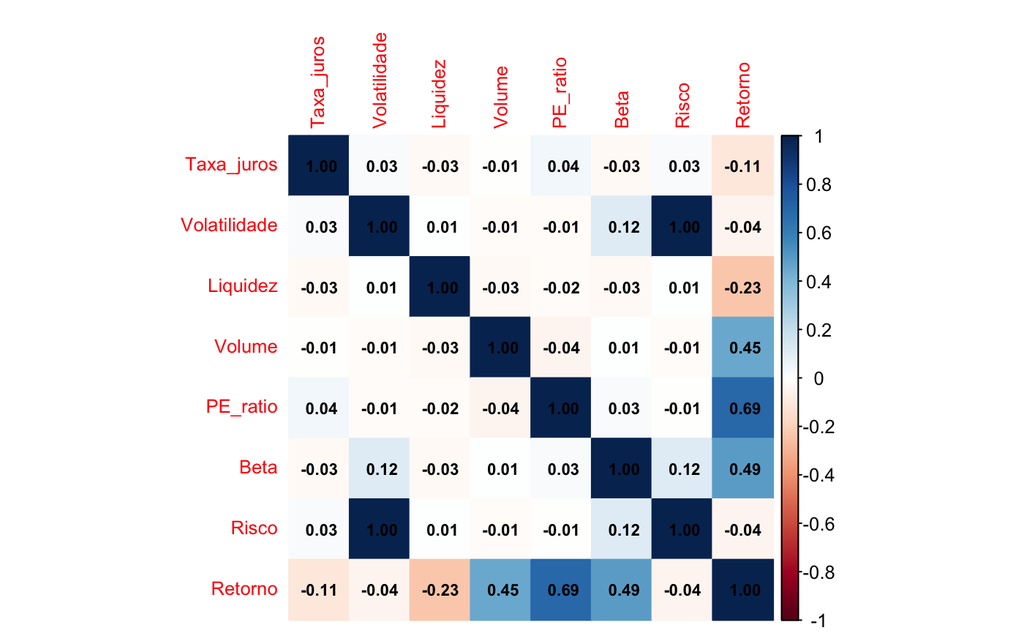

```r
# Análise de correlação (exceto variáveis categóricas)
library(corrplot)
library(dplyr)

dados_numericos <- dados_limpos %>% select(where(is.numeric)) #  pegando apenas as variáveis numéricas.

matriz_correlacao <- cor(dados_numericos, use = "complete.obs")

corrplot(matriz_correlacao, method = "color", addCoef.col = "black",
         tl.cex = 0.8, number.cex = 0.7, mar = c(0,0,1,0))
```

```r
NA
NA
```

### 3.2 Variável numérica em função de categórica

Vamos agora analisar o boxplot da nossa variável alvo em relação com a única variável categórica do nosso dataset.

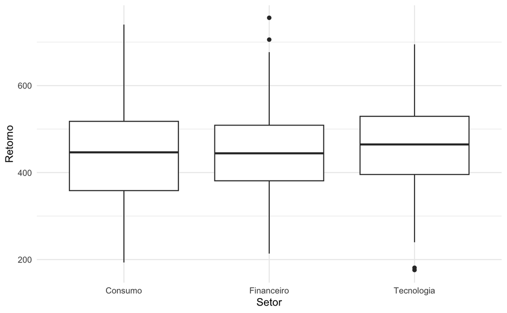

```r
library(ggplot2)

# Boxplots para variáveis categóricas
ggplot(dados_limpos, aes(x = Setor, y = Retorno)) + geom_boxplot() + theme_minimal()
```

A seguir, a análise do boxplot:

- Em termos de **mediana**, o setor de Tecnologia apresenta o melhor valor de Retorno.
- O setor de Tecnologia apresenta uma distribuição de retornos mais simétrica, com a mediana centralizada e caudas equilibradas, ainda que haja alguns outliers inferiores.
- O setor de consumo mostra uma assimetria, com a mediana ligeiramente deslocada e uma cauda superior mais longa.
- Já o setor Financeiro apresenta uma distribuição bem parecida com o setor de tecnologia.

Decidimos seguir com nossa análise deixando os outliers da nossa variável alvo pois, esse valores não decorrem de erros, mas sim de ativos que por motivos que não sabemos (como ventos econcômicos, noticias que afetam todo o mundo ou até mesmo oscilações adruptas do mercado), resultando assim em retornos acima ou abaixo da média.

# 4. Análise de Regressão

## 4.1 Análise de Multicolinearidade

A seguir, iremos utilizar a função Variance Inflation Factor(VIF) para podermos identificar se existe multicolinearidade entre as variáveis.

```r
#install.packages("car")
library(dplyr)
library(car)
modelo <- lm(Retorno ~ Taxa_juros + Volatilidade + Liquidez + Volume + PE_ratio + Beta + Risco, data = dados_limpos)

vif(modelo)
```

```
  Taxa_juros Volatilidade     Liquidez       Volume     PE_ratio         Beta        Risco
    1.004448  1262.581768     1.002842     1.002886     1.008147     1.016747  1262.562550
```

Portanto, a partir da análise do VIF podemos tirar algumas conclusões sobre as nossas variáveis:

- **Volatilidade e Risco**: Apresentam valores de VIF extremamente elevados (em torno de 1262), sugerindo uma **colinearidade severa** entre essas duas variáveis.
- Demais Variáveis (Taxa_juros, Liquidez, Volume, PE_ratio, Beta): Possuem valores de VIF próximos de 1, o que indica **ausência de problemas de multicoliaridade**.

Tendo em vista a alta colinearidade entre as variáveis Volatilidade e Risco, devemos escolher apenas uma delas na nossa base de dados, assim, vamos evitar distorções nos coeficientes e conseguimos aprimorar a estabilidade da nossa variável alvo. A análise de qual variável será mantida será realizada posteriormente.

# 5. Seleção de modelo

Nessa seção iremos analisar nossa base de dados a fim de selecionar um modelo que melhor se ajuste, pois foi percebido um caso de multicolinearidade. Nesse sentido, faremos uma análise exploratória manual removendo certas variáveis e verificando o comportamento de cada um dos modelos.

## 5.1 Multicolinearidade: volatilidade ou risco?

Percebemos pelas análises antes feitas que existe uma multicolinearidade significativa entre `Volatilidade` e `Risco`. Nesse sentido, devemos remover uma dessas variáveis. A análise feita a seguir nos fornecer informações relevantes para selecionarmos uma das variáveis.

### 5.1.1 Sem volatilidade (com Risco)

```r
mod_sem_volatilidade <- update(modelo, . ~ . - Volatilidade)

summary(mod_sem_volatilidade)
```

```
Call:
lm(formula = Retorno ~ Taxa_juros + Liquidez + Volume + PE_ratio +
    Beta + Risco, data = dados_limpos)

Residuals:
    Min      1Q  Median      3Q     Max
-32.923  -7.257  -0.126   7.541  31.268

Coefficients:
            Estimate Std. Error t value Pr(>|t|)
(Intercept) 18.06711    3.35664   5.382 1.12e-07 ***
Taxa_juros  -0.79546    0.02786 -28.551  < 2e-16 ***
Liquidez    -1.05986    0.02374 -44.646  < 2e-16 ***
Volume       3.99310    0.03777 105.711  < 2e-16 ***
PE_ratio     4.68993    0.02979 157.447  < 2e-16 ***
Beta         2.99693    0.02844 105.368  < 2e-16 ***
Risco       -0.47013    0.02643 -17.786  < 2e-16 ***
---
Signif. codes:  0 ‘***’ 0.001 ‘**’ 0.01 ‘*’ 0.05 ‘.’ 0.1 ‘ ’ 1

Residual standard error: 10.43 on 517 degrees of freedom
Multiple R-squared:  0.9899,    Adjusted R-squared:  0.9897
F-statistic:  8406 on 6 and 517 DF,  p-value: < 2.2e-16
```

Importante destacar pela saída acima que todas as variáveis são significativas, e nosso $R^2=0.9897$, ou seja, se manteve alto. A seguir verificamos o valor do $AIC$.

```r
AIC(mod_sem_volatilidade)
```

```
[1] 3953.048
```

```r
BIC(mod_sem_volatilidade)
```

```
[1] 3987.14
```

### 5.1.2 Sem risco (com volatilidade)

```r
mod_sem_risco <- update(modelo, . ~ . - Risco)

summary(mod_sem_risco)
```

```
Call:
lm(formula = Retorno ~ Taxa_juros + Volatilidade + Liquidez +
    Volume + PE_ratio + Beta, data = dados_limpos)

Residuals:
    Min      1Q  Median      3Q     Max
-32.718  -7.440  -0.136   7.724  30.656

Coefficients:
             Estimate Std. Error t value Pr(>|t|)
(Intercept)  18.18788    3.34907   5.431 8.65e-08 ***
Taxa_juros   -0.79536    0.02779 -28.618  < 2e-16 ***
Volatilidade -0.50354    0.02813 -17.904  < 2e-16 ***
Liquidez     -1.05963    0.02368 -44.749  < 2e-16 ***
Volume        3.99279    0.03768 105.967  < 2e-16 ***
PE_ratio      4.68907    0.02971 157.810  < 2e-16 ***
Beta          2.99710    0.02837 105.641  < 2e-16 ***
---
Signif. codes:  0 ‘***’ 0.001 ‘**’ 0.01 ‘*’ 0.05 ‘.’ 0.1 ‘ ’ 1

Residual standard error: 10.4 on 517 degrees of freedom
Multiple R-squared:  0.9899,    Adjusted R-squared:  0.9898
F-statistic:  8449 on 6 and 517 DF,  p-value: < 2.2e-16
```

Importante destacar pela saída acima que todas as variáveis são significativas, e nosso $R^2=0.9897$, ou seja, se manteve alto. A seguir verificamos o valor do $AIC$.

```r
AIC(mod_sem_risco)
```

```
[1] 3950.42
```

```r
BIC(mod_sem_risco)
```

```
[1] 3984.512
```

### 5.1.4 Conclusão

Portanto, dada a análise, escolhemos o modelo **sem risco e com volatilidade.**.

## 5.2 Variável categórica: com ou sem setor?

Nessa subseção iremos avaliar como o modelo se comporta com a adição ou a remoção da variável categórica `Setor`. Vale ressaltar que utilizamos o modelo atualizado. Ou seja, estamos realizando análise sobre o modelo sem a variável `Risco`, que foi removida baseada em avaliações anteriores.

### 5.2.1 Sem setor

```r
mod_sem_setor <- mod_sem_risco
summary(mod_sem_risco)
```

```
Call:
lm(formula = Retorno ~ Taxa_juros + Volatilidade + Liquidez +
    Volume + PE_ratio + Beta, data = dados_limpos)

Residuals:
    Min      1Q  Median      3Q     Max
-32.718  -7.440  -0.136   7.724  30.656

Coefficients:
             Estimate Std. Error t value Pr(>|t|)
(Intercept)  18.18788    3.34907   5.431 8.65e-08 ***
Taxa_juros   -0.79536    0.02779 -28.618  < 2e-16 ***
Volatilidade -0.50354    0.02813 -17.904  < 2e-16 ***
Liquidez     -1.05963    0.02368 -44.749  < 2e-16 ***
Volume        3.99279    0.03768 105.967  < 2e-16 ***
PE_ratio      4.68907    0.02971 157.810  < 2e-16 ***
Beta          2.99710    0.02837 105.641  < 2e-16 ***
---
Signif. codes:  0 ‘***’ 0.001 ‘**’ 0.01 ‘*’ 0.05 ‘.’ 0.1 ‘ ’ 1

Residual standard error: 10.4 on 517 degrees of freedom
Multiple R-squared:  0.9899,    Adjusted R-squared:  0.9898
F-statistic:  8449 on 6 and 517 DF,  p-value: < 2.2e-16
```

```r
AIC(mod_sem_setor)
```

```
[1] 3950.42
```

```r
BIC(mod_sem_setor)
```

```
[1] 3984.512
```

### 5.2.2 Com setor

```r
mod_com_setor <- update(mod_sem_risco, . ~ . + Setor)
summary(mod_com_setor)
```

```
Call:
lm(formula = Retorno ~ Taxa_juros + Volatilidade + Liquidez +
    Volume + PE_ratio + Beta + Setor, data = dados_limpos)

Residuals:
    Min      1Q  Median      3Q     Max
-32.994  -7.227  -0.097   7.540  30.594

Coefficients:
                Estimate Std. Error t value Pr(>|t|)
(Intercept)     16.40418    3.35991   4.882  1.4e-06 ***
Taxa_juros      -0.79653    0.02755 -28.910  < 2e-16 ***
Volatilidade    -0.50266    0.02791 -18.012  < 2e-16 ***
Liquidez        -1.06097    0.02347 -45.203  < 2e-16 ***
Volume           3.98814    0.03738 106.690  < 2e-16 ***
PE_ratio         4.69119    0.02947 159.180  < 2e-16 ***
Beta             2.99857    0.02816 106.489  < 2e-16 ***
SetorFinanceiro  3.64844    1.07605   3.391 0.000751 ***
SetorTecnologia  2.16522    1.12604   1.923 0.055048 .
---
Signif. codes:  0 ‘***’ 0.001 ‘**’ 0.01 ‘*’ 0.05 ‘.’ 0.1 ‘ ’ 1

Residual standard error: 10.31 on 515 degrees of freedom
Multiple R-squared:  0.9901,    Adjusted R-squared:   0.99
F-statistic:  6456 on 8 and 515 DF,  p-value: < 2.2e-16
```

```r
AIC(mod_com_setor)
```

```
[1] 3942.731
```

```r
BIC(mod_com_setor)
```

```
[1] 3985.345
```

### 5.2.4 Conclusão

Baseado na análise acima, podemos concluir que o modelo com Setor (e sem Risco) melhor se ajusta e é o modelo desejável.

## 5.3 Escolha do modelo `mod_final`

A partir de agora, nos referiremos ao modelo escolhido, ou seja, o modelo **sem risco e com setor**, como `modelo_final`. Com isso podemos realizar mais análises e comparar o modelo escolhido com o modelo original.

```r
modelo_final <- mod_com_setor
```

# 6 Análise de Resíduos / Checando pressupostos

Nessa seção iremos fazer a análise de resíduos e checar pressupostos do modelo original e o modelo de escolha `modelo_final`. Desta forma conseguimos notar uma diferença significativa entre os modelos.

## 6.1 Checando pressupostos com gráficos básicos

### 6.1.1 Modelo final

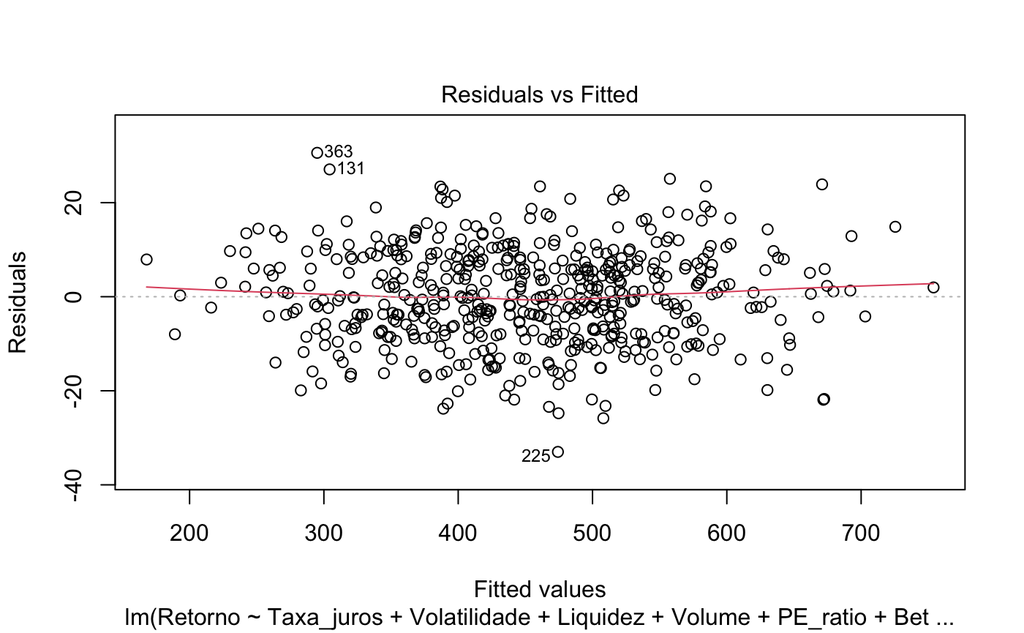

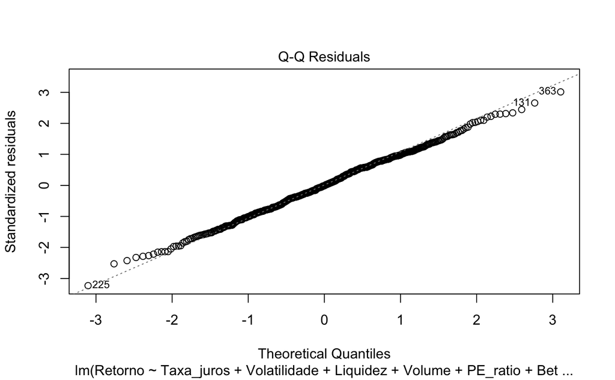

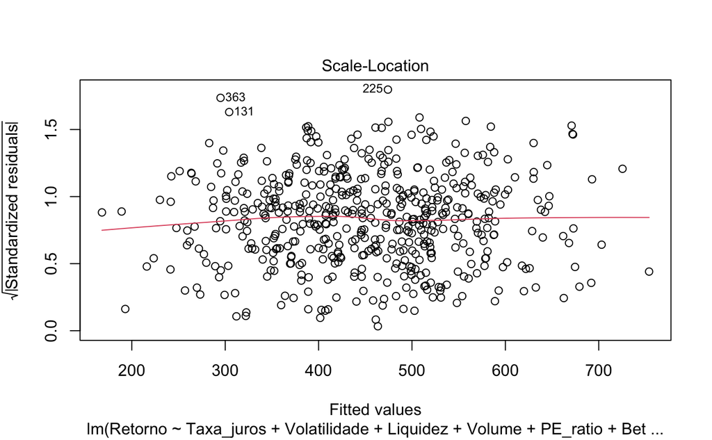

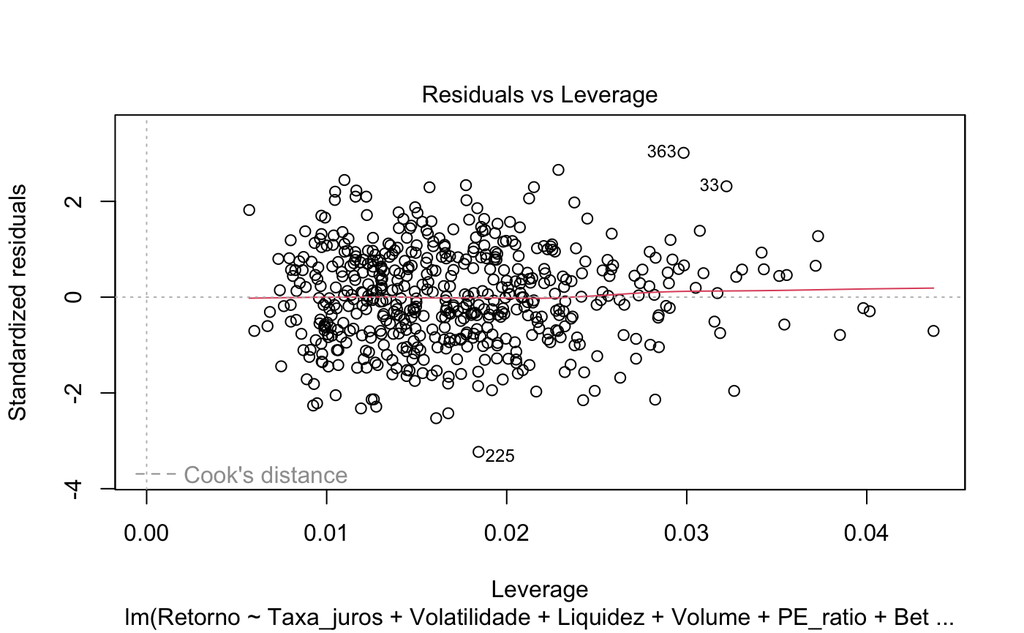

```r
plot(modelo_final)
```

Os gráficos de resíduos gerados pelo R base fornecem quatro visualizações importantes:

1. **Resíduos vs Valores Ajustados**: Este gráfico ajuda a verificar a homocedasticidade (variância constante dos resíduos). No nosso caso, os pontos parecem estar distribuídos aleatoriamente em torno de zero, sem padrões claros, o que sugere que o pressuposto de homocedasticidade pode estar sendo atendido.
2. **Q-Q Plot**: Avalia a normalidade dos resíduos. Os pontos seguem aproximadamente a linha diagonal, indicando que a distribuição dos resíduos é próxima da normal.
3. **Scale-Location Plot**: Outra forma de avaliar homocedasticidade. A linha vermelha relativamente plana sugere variância constante.
4. **Resíduos vs Leverage**: Identifica pontos influentes. Não observamos pontos que ultrapassem significativamente as linhas de contorno (linhas tracejadas), indicando ausência de pontos com alta influência.

## 6.2 Análise aprofundada com o pacote `easystats`

### 6.2.1 Normalidade

#### 6.2.1.1 Sobre o modelo sem modificações: `modelo`

```r
library(easystats)
check_normality(modelo)
```

```
OK: residuals appear as normally distributed (p = 0.636).
```

#### 6.2.1.2 Sobre o modelo selecionado: `modelo_final`

```r
library(easystats)

check_normality(modelo_final)
```

```
OK: residuals appear as normally distributed (p = 0.889).
```

#### 6.2.1.3 Conclusão

A partir dos dados fornecidos anteriormente, podemos concluir que a normalidade do modelo continua com $valor-p$ maior. Isto significa que os resíduos do modelo segue distribuição normal, logo, os valores de $p$ e $IC$ são confiáveis para fazer inferências.

### 6.2.2 Multicolinearidade

#### 6.2.2.1 Sobre o modelo sem modificações: `modelo`

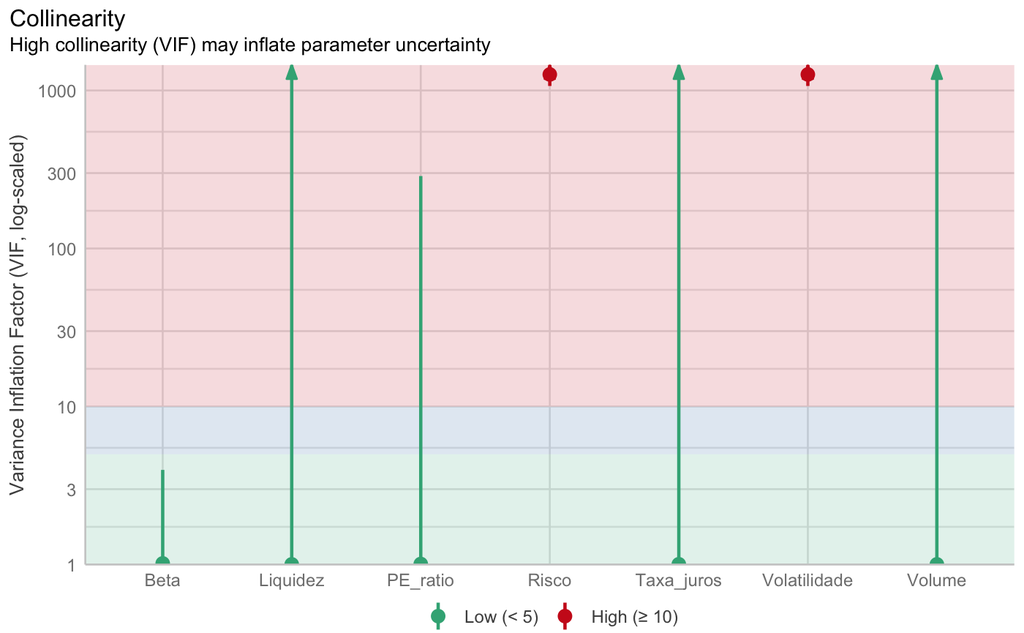

```r
check_collinearity(modelo) %>% plot()
```

#### 6.2.2.2 Sobre o modelo selecionado: `modelo_final`

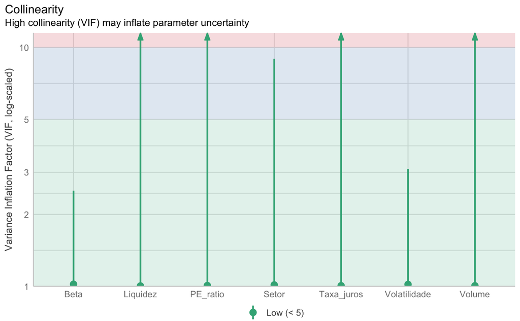

```r
check_collinearity(modelo_final) %>% plot()
```

#### 6.2.2.3 Conclusão

Considerando os gráficos acima, podemos perceber que existe multicolinearidade na base de dados original, e isso pode atrapalhar a análise dos dados, pois o modelo não saberá distinguir quem tem uma influência maior. Por esse motivo, em seções anteriores, fizemos um estudo de qual das duas variáveis `Volatilidade` ou `Risco` deveriam ser removidas. Podemos perceber, a partir do gráfico da seção 6.2.2.2, que a multicolinearidade não existe mais depois de remover `Risco`, deixando nosso modelo sem multicolinearidade.

# 7 Conclusão

## 7.1 O que considerar em um investimento?

Com base em toda a análise que realizamos, é possível concluir que o investidor deve considerar a variável `PE_Ratio` em seus investimentos. Isso porque essa variável mostrou maior correlação com o retorno de uma ativo financeiro.

Ou seja, a razão preço/lucro, que compara o preço da ação com um lucro por ação, deve ter atenção redobrada de um investidor caso ele queira ter retornos maiores.

# 7.2. O que não considerar em um investimento?

De maneira análoga, podemos concluir que o investidor não considere a variável `Risco`, mas sim `Volatilidade`. Isso porque essas duas variáveis tentam explicar o retorno de um ativo, o que pode, além de atrapalhar a análise estatística, o próprio investidor.

Isto é, a medida de variação dos preços de um ativo ao longo do tempo, indicando risco de flutuações é o que deve ser levado em conta.

Variáveis como Liquidez e Taxa de juros mostraram relação inversa com os retornos, enquanto Risco e Volatilidade são redundantes — a última é suficiente para medir flutuações de preço.